# PCOD

Sathya

2024-11-15

[Link to dataset](https://www.kaggle.com/datasets/cm037divya/pcos-dataset/data)

```r
# Assuming the dataset is named pcod_data
data <- read.csv("C:/Users/DELL/Downloads/archive (21)/PCOS_extended_dataset.csv")

# Summary statistics
summary(data)
```

```
##      Sl..No      Patient.File.No.   PCOS..Y.N.      Age..yrs.
##  Min.   :  1.0   Min.   :  1.0    Min.   :0.000   Min.   :20.00
##  1st Qu.:132.0   1st Qu.:132.0    1st Qu.:0.000   1st Qu.:28.00
##  Median :267.0   Median :267.0    Median :0.000   Median :31.00
##  Mean   :266.6   Mean   :266.6    Mean   :0.304   Mean   :31.35
##  3rd Qu.:395.0   3rd Qu.:395.0    3rd Qu.:1.000   3rd Qu.:35.00
##  Max.   :541.0   Max.   :541.0    Max.   :1.000   Max.   :48.00
##
##   Weight..Kg.       Height.Cm.         BMI         Blood.Group
##  Min.   : 30.74   Min.   :136.5   Min.   :11.94   Min.   :11.00
##  1st Qu.: 52.25   1st Qu.:152.2   1st Qu.:21.77   1st Qu.:13.00
##  Median : 58.54   Median :156.4   Median :24.19   Median :14.00
##  Mean   : 59.53   Mean   :156.4   Mean   :24.28   Mean   :13.79
##  3rd Qu.: 65.52   3rd Qu.:160.1   3rd Qu.:26.60   3rd Qu.:15.00
##  Max.   :113.38   Max.   :180.4   Max.   :40.45   Max.   :18.00
##
##  Pulse.rate.bpm. RR..breaths.min.    Hb.g.dl.       Cycle.R.I.
##  Min.   :13.00   Min.   :16.00    Min.   : 8.50   Min.   :2.000
##  1st Qu.:72.00   1st Qu.:18.00    1st Qu.:10.50   1st Qu.:2.000
##  Median :72.00   Median :18.00    Median :11.00   Median :2.000
##  Mean   :73.24   Mean   :19.23    Mean   :11.15   Mean   :2.535
##  3rd Qu.:74.00   3rd Qu.:20.00    3rd Qu.:11.70   3rd Qu.:4.000
##  Max.   :82.00   Max.   :28.00    Max.   :14.80   Max.   :5.000
##
##  Cycle.length.days. Marraige.Status..Yrs. Pregnant.Y.N.    No..of.abortions
##  Min.   : 0.000     Min.   : 0.000        Min.   :0.0000   Min.   :0.000
##  1st Qu.: 5.000     1st Qu.: 4.000        1st Qu.:0.0000   1st Qu.:0.000
##  Median : 5.000     Median : 7.000        Median :0.0000   Median :0.000
##  Mean   : 4.973     Mean   : 7.579        Mean   :0.3815   Mean   :0.301
##  3rd Qu.: 5.000     3rd Qu.:10.000        3rd Qu.:1.0000   3rd Qu.:0.000
##  Max.   :12.000     Max.   :30.000        Max.   :1.0000   Max.   :5.000
##                     NA's   :3
##  I...beta.HCG.mIU.mL. II....beta.HCG.mIU.mL.  FSH.mIU.mL.
##  Min.   :    1.30     Length:2000            Min.   :   0.21
##  1st Qu.:    1.99     Class :character       1st Qu.:   3.39
##  Median :   12.37     Mode  :character       Median :   4.86
##  Mean   :  640.60                            Mean   :  12.94
##  3rd Qu.:  300.53                            3rd Qu.:   6.47
##  Max.   :32460.97                            Max.   :5052.00
##
```

[output cut: 41 more lines]

```
##  Min.   : 0.00    Min.   : 0.000   Min.   : 0.00        Min.   : 0.00
##  1st Qu.: 3.00    1st Qu.: 3.000   1st Qu.:13.00        1st Qu.:13.00
##  Median : 5.00    Median : 6.000   Median :15.00        Median :16.00
##  Mean   : 6.09    Mean   : 6.503   Mean   :14.88        Mean   :15.41
##  3rd Qu.: 8.25    3rd Qu.: 9.000   3rd Qu.:18.00        3rd Qu.:18.00
##  Max.   :22.00    Max.   :20.000   Max.   :24.00        Max.   :24.00
##
##  Endometrium..mm.
##  Min.   : 0.000
##  1st Qu.: 7.100
##  Median : 8.435
##  Mean   : 8.572
##  3rd Qu.: 9.877
##  Max.   :18.675
##
```

```r
# Check the dimensions of the dataset
cat("Number of Observations:", nrow(data), "\n")
```

```
## Number of Observations: 2000
```

```r
cat("Number of Variables:", ncol(data), "\n")
```

```
## Number of Variables: 44
```

##These are my few selected variables:

```r
selected_columns <- c("PCOS..Y.N.","Age.","BMI","LH.mIU.mL.", "TSH..mIU.L.","BP._Systolic..mmHg.","BP._Diastolic..mmHg.","Fast.food..Y.N","Reg.Exercise.Y.N.")
```

##Brief description: ##PCOS(Y/N) : Identify the pCOS present or not.

##Age : Used for calculation of BMI .

##BMI : A key physiological factor that is commonly associated with the development of PCOS, particularly due to its role in obesity and hormonal imbalances.

##LH: High LH levels, particularly in relation to FSH, are a hallmark of PCOS and can lead to ovulatory dysfunction.

##TSH: Imbalances in TSH, especially hypothyroidism, can exacerbate PCOS symptoms like irregular periods and weight gain.

##BP systolic:High systolic blood pressure is often associated with Polycystic Ovary Syndrome (PCOS) due to underlying metabolic disturbances, such as insulin resistance and hormonal imbalances.

## Bp Diastolic: High diastolic blood pressure is often associated with Polycystic Ovary Syndrome (PCOS) due to underlying metabolic disturbances, such as insulin resistance and hormonal imbalances.

##Fast food : Increased fast food associated with increase in PCOD.

##Regular exercise : Regular exercise can decrease the risk of PCOD.

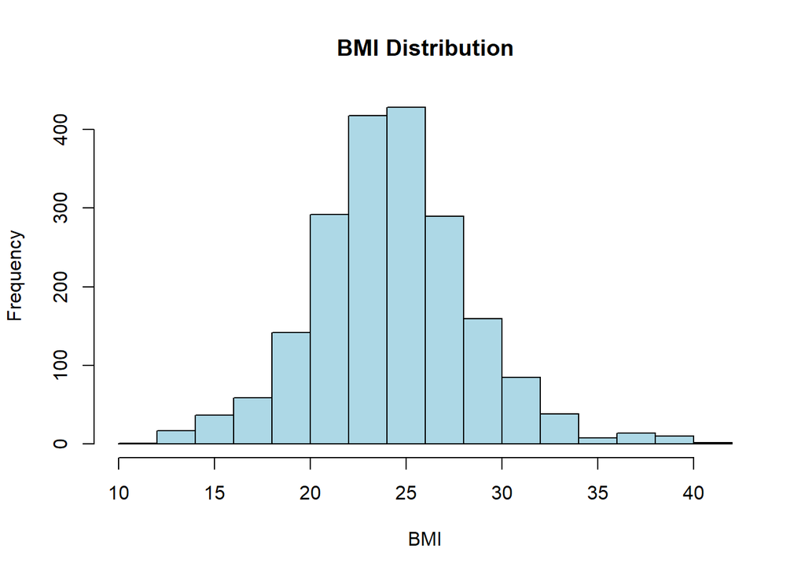

```r
hist(data$BMI,
     main = "BMI Distribution",
     xlab = "BMI",
     ylab = "Frequency",
     col = "lightblue",
     border = "black")
```

##The plot shows a roughly normal distribution of BMI, with a peak around the healthy range. A slight rightward skew suggests potential outliers with high BMI values.

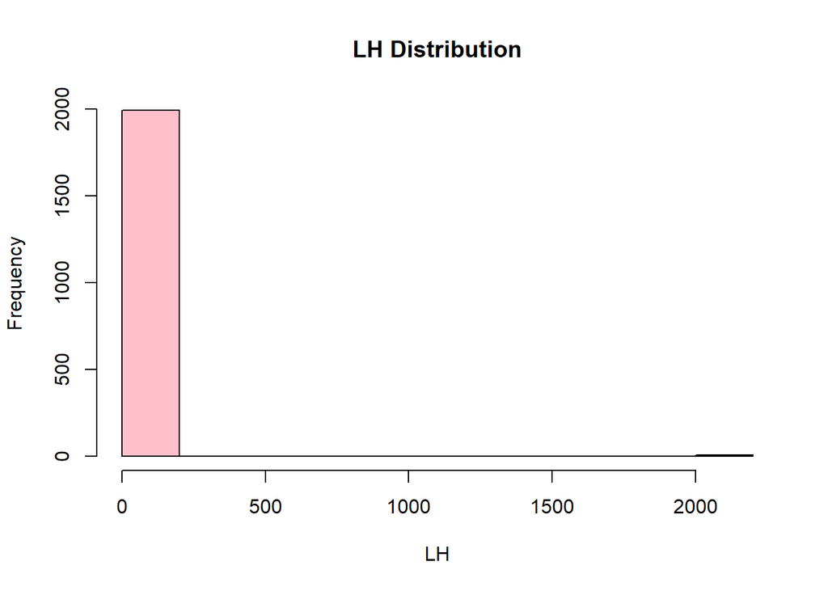

```r
hist(data$LH.mIU.mL.,
     main = "LH Distribution",
     xlab = "LH",
     ylab = "Frequency",
     col = "pink",
     border = "black")
```